# Data Science For Good

1802560

December 2, 2018

# Summary

A report submitted in fulfilment of the requirements for Course MA304, Department of Mathematics, Univeristy of Essex.

# Introduction

Police departments across the United States have joined the National Justice Database, to use advanced analytics to diagnose disparities in policing, shed light on police behavior, and provide actionable recommendations. With the increase in the number of crimes, the US police has gathered data all around the country to perform analytics to identify the sensitive issues which help them in identifying the cause of crimes and also helps in finding any biasing in policing.

The aim of this report to analyze the disparities in policing for the various crimes committed by people. In particular, I have analyzed the offenses in the Dallas city. There are a total 2384 crimes happened in Dallas city during the year 2016. This report mainly focuses on spatial analytics which involves geo maps analyzing various crimes in different places and the major divisions in the city where the crime is taking place and discussing the factors which may directly or indirectly involve for the cause of crimes and diagnoses disparities in policing.

# Data

The data is downloaded from the Kaggle website under the competition “Data Science for Good: Center for Policing Equity”. The data contains standardized police behavior according to crimes committed by various people across the United States. There are Metadata information, Background Details, Shapefiles, offense details. I have particularly worked on the offenses file for the Dallas city, in which there are 47 different attributes in the data, which gives information about , incident date and time, officer details such as ID, gender, race, experience, injury status, injury type, hospitalization details, and Subject details such as ID, race, Gender, injury status, injury type, arrest status, description, reporting area and location details of offence, and type of force used on subject.

In addition to this, the shape files give information in the form of polygons, and meta data information, which mainly focuses on background data such as poverty, race, gender, income, and education which also a plays a role in the number of offenses being committed.

I have used subject race, location details, subject description, shapefiles and background data to get the insights from the data to perform spatial analytics. The shapefiles provided by the Kaggle for Dallas city does not give much information, so I have downloaded shapefiles for Dallas city and mapped my variables to the shapefile by using GEOID’s.

# Methods

I have used statistical analysis such as Minimum, Maximum, Frequency Distribution and cumulative frequency distribution, correlation and performed escape analysis and I have used the following packages, leaflet, tmaps -for plotting maps and shapefiles, knitr -for plotting tables and tigris -for lookup tables to get the FISP code for Dallas city.

# Report Details

There are 1690 words in this report and I have used R markdown for plotting maps.

## 1.Introduction Graph

The below dynamic graph shows the number of crimes happening around the Dallas city. The graph shows, 3 different colors, Orange (most number of crimes), Yellow(second most number of crimes) and Green(least number of crimes) at each stage. On each level of zoom, the graph dynamically changes by splitting the number of crimes in each selected region. This graph help in analyzing the number of crimes in each region from an areal view.

[interactive chart not shown]

A Hypothesis can be made, that most crimes happened in highly populated areas. As very less population lives far away city, the crimes are less when compared with the crimes at the center of the city. Most of the crimes are happening in the center of the city because the population is more at the center of the city.

## 2.Crimes committed according to divisions

The below graph shows the crimes spread across 7 divisions in Dallas city. The city is being divided into 7 divisions, Central, Northcentral, Northwest, Northeast, Southcentral, Southwest, and Southeast. Each division is represented by different colors. By selecting filter on the right side, the crimes in each division is highlighted.

[interactive chart not shown]

As most of the population and major offices, shopping malls, and many events happen at the center of each division, the crimes are more at the center division of the city when compared with the other divisions.

Central Region has the highest number of crimes(564)with 23% of crimes and in the Northwest region with the least number of crimes 192 with 8.13% of the total. The below table shows the percentage of crimes happening in each division.

| Divisions in Dallas | Number of Crimes | Percentage of crimes |
| --- | --- | --- |
| Central | 564 | 23.65% |
| North Central | 320 | 13.42% |
| North East | 342 | 14.34% |
| North West | 192 | 8.13% |
| South Central | 311 | 13.04% |
| South East | 363 | 15.22% |
| South West | 298 | 12.50% |
| Total | 2384 | 100% |

## 3.Map Showing state of the subjects during each offense

The graph shows the state of the subject during offenses, There are 6 major issues subject gets involved in during offenses, They are Alchohol, Drugs, Marijuana, Mentally Unstable and for other unknown reasons. Each of these are highlighted by different colors.

[interactive chart not shown]

From the spatial analysis, it is clear that all types of incidents are happening all over Dallas, There is no particular pattern observed. But, a hypothesis is that crimes occur immediately after consumption of alcohol and drugs. People travel very less when they are boozed, so drugs are available all over Dallas, especially at the center of the city.

The following table shows the different types of cases involved in offenses.

| Types of Incidents in Dallas | Number of Incidents | Percentage of Incidents |
| --- | --- | --- |
| Alchohol | 383 | 16.06% |
| Alchohol and unknown drugs | 281 | 11.78% |
| Marijuana | 51 | 2.13% |
| Mentally unstable | 413 | 17.32% |
| Unknown Drugs | 319 | 13.38% |
| Unknown | 318 | 13.33% |
| Others | 578 | 24.24% |
| Total | 2384 | 100% |

## 4.Plot showing different races involved in crimes at each division

#### First Graph is Black vs White Comparision and Second Graph is Black vs Hispanic comparison

The radius of each bubble describes the number of crimes committed in each division. The blue circle is the number of crimes committed in each division., the red color circle is for the number of crimes committed by black people and the black color circle is the number of crimes committed by white people in the first graph and Hispanic people in the second graph.

[interactive chart not shown]

The most of the crimes in entire Dallas city are committed by Blacks(55.95%) followed by Hispanic(22.02%) followed by whites(19.75%).

A pattern is identified that most of the crimes in the central, and south regions are committed by blacks, whereas comparatively, most crimes in the North Central are shared by Blacks, Whites, and Hispanics equally.

The hypothesis is, even though white commit less number of crimes in overall, they are involved in most of the crimes in North Central region and in the same way Hispanic people are committing most of the crimes in South west region.

The following table showing crimes distribution according to subject race in the Dallas city.

| Subject race involved in crime | Number of Incidents | Percentage of Incidents |
| --- | --- | --- |
| Black | 1334 | 55.95% |
| Hispanic | 525 | 22.02% |
| White | 471 | 19.75% |
| Others | 57 | 2.39% |
| Total | 2384 | 100% |

## 5.Subjetcs Escape Ratio in different Regions:

The below map shows the subjects escape ratio from arrests at different regions after the crime is committed. The size of each bubble depicts the percentage of people gets escaped from arrests after the crime is being committed.

[interactive chart not shown]

From the above map, the following conclusions can be made, Even though the most number of crimes are in the central division, the subject gets arrested most of the times. But the Subjects are escaped in North Central and South West regions. This illustrates that patrolling is very strict in the Central Region and North west, whereas patroling is comparatively weaker in North Central, Northeast and South West regions.

Interestingly, Most of the offenses committed by White people are more in the north region and most of the crimes committed by Black people are more in the south and central region. So relatively, white people are not being arrested when caught committed crime than black people during crime incident.

The below table shows Arrest and Escape Percentages in each division.

| DIVISION | Number_of_offenses | Arrest_Yes | Arrest_No | Percentage_of_Arrest | Escape_Ratio |
| --- | --- | --- | --- | --- | --- |
| Central | 564 | 500 | 64 | 88.65 | 11.34 |
| North Central | 320 | 261 | 60 | 81.56 | 18.75 |
| North East | 342 | 290 | 53 | 84.79 | 15.49 |
| North West | 192 | 172 | 21 | 89.58 | 10.93 |
| South Central | 311 | 268 | 44 | 86.17 | 14.14 |
| South East | 363 | 315 | 49 | 86.77 | 13.49 |
| South West | 298 | 249 | 50 | 83.55 | 16.77 |

## 6.Analysis using Shapefiles

The following 4 shapefiles showing, Black Population, White Population, Median Income and Number of people below the poverty level. I have used external shapefiles and merged the data from existing background data from Race, Median Income and Poverty. The number of people living in particular area is indicated in ascending order of color from light to dark.

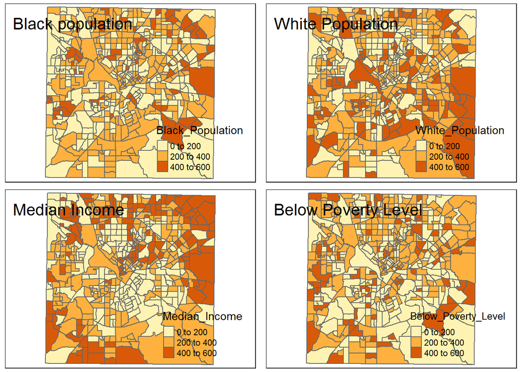

Moreover, there is a negative correlation between the Median Income and Number of people living below poverty levels. By hypothesis, People who have stable income tend to live in the rich and quality areas than the people with low income.

# Results

From the above analysis, I have used, geo locations, divisions information, and race, poverty, income levels. Most number of crimes happens in highly populated areas. As the center division of city is densely populated due to shopping, offices and entertainment activities more people are located at the center of the city as well of the center of North and South divisions. so this leads to a higher number of crimes in those divisions.

Most of the offenses involve alcohol, drugs, and mentally unstable cases. People often do not travel after consumption of alcohol or drugs, So people who committed crimes are boozed up when they involved in crime. But this also highlights the fact that, Drugs and Marijuana are available all over Dallas.

# Discussion

Most people who commit crimes are black people, followed by Hispanic and white people. Even though whites are more populous than black, the crimes committed by blacks are more. There are some factors which are directly or indirectly related to offenses committed by Black people. The Median income and poverty level also plays a role in committing a crime. But I have not analyzed the education details and more background information about Dallas city in this report. By analyzing a few important factors such as Age, Family income, Occupation, and past criminal records, a detailed analysis can be carried out.

In future, this work extends by analyzing background information from the other variables and also analyzing the officer details and identifying any pattern in arrests. The main challenges involved are generalizing the black people as offenders. There are many socio, economic factors which are not included in the data, which may directly or indirectly make the black people as a point of targets in crimes.